# Movies Genres Analysis

```python
import pandas as pd
```

Research (Q's):

1. Which genres are the most common?
2. Which genres have the high avg. budget, revenue and profit?
3. Which genres have the high avg. popularity?
4. Which genres have the highest number of movies with an voting avg. >=8?

```python
movies = pd.read_csv(r"C:\Users\aneesh.patel\Python Scripts\Data Analysis Course\Projects\Movie Genres\imdb_movies.csv")
movies.info()
```

```
<class 'pandas.core.frame.DataFrame'>
RangeIndex: 10866 entries, 0 to 10865
Data columns (total 21 columns):
 #   Column                Non-Null Count  Dtype
---  ------                --------------  -----
 0   id                    10866 non-null  int64
 1   imdb_id               10856 non-null  object
 2   popularity            10866 non-null  float64
 3   budget                10866 non-null  int64
 4   revenue               10866 non-null  int64
 5   original_title        10866 non-null  object
 6   cast                  10790 non-null  object
 7   homepage              2936 non-null   object
 8   director              10822 non-null  object
 9   tagline               8042 non-null   object
 10  keywords              9373 non-null   object
 11  overview              10862 non-null  object
 12  runtime               10866 non-null  int64
 13  genres                10843 non-null  object
 14  production_companies  9836 non-null   object
 15  release_date          10866 non-null  object
 16  vote_count            10866 non-null  int64
 17  vote_average          10866 non-null  float64
 18  release_year          10866 non-null  int64
 19  budget_adj            10866 non-null  float64
 20  revenue_adj           10866 non-null  float64
dtypes: float64(4), int64(6), object(11)
memory usage: 1.7+ MB
```

```python
pd.set_option('display.max.rows',11000)
pd.set_option('display.max.columns',22)
```

```python
movies.head()
```

|  | id | imdb_id | popularity | budget | revenue | original_title | cast | homepage | director | tagline | keywords | overview | runtime | genres | production_companies | release_date | vote_count | vote_average | release_year | budget_adj | revenue_adj |
| --- | --- | --- | --- | --- | --- | --- | --- | --- | --- | --- | --- | --- | --- | --- | --- | --- | --- | --- | --- | --- | --- |
| 0 | 135397 | tt0369610 | 32.985763 | 150000000 | 1513528810 | Jurassic World | Chris Pratt\|Bryce Dallas Howard\|Irrfan Khan\|Vi... | http://www.jurassicworld.com/ | Colin Trevorrow | The park is open. | monster\|dna\|tyrannosaurus rex\|velociraptor\|island | Twenty-two years after the events of Jurassic ... | 124 | Action\|Adventure\|Science Fiction\|Thriller | Universal Studios\|Amblin Entertainment\|Legenda... | 6/9/15 | 5562 | 6.5 | 2015 | 1.379999e+08 | 1.392446e+09 |
| 1 | 76341 | tt1392190 | 28.419936 | 150000000 | 378436354 | Mad Max: Fury Road | Tom Hardy\|Charlize Theron\|Hugh Keays-Byrne\|Nic... | http://www.madmaxmovie.com/ | George Miller | What a Lovely Day. | future\|chase\|post-apocalyptic\|dystopia\|australia | An apocalyptic story set in the furthest reach... | 120 | Action\|Adventure\|Science Fiction\|Thriller | Village Roadshow Pictures\|Kennedy Miller Produ... | 5/13/15 | 6185 | 7.1 | 2015 | 1.379999e+08 | 3.481613e+08 |
| 2 | 262500 | tt2908446 | 13.112507 | 110000000 | 295238201 | Insurgent | Shailene Woodley\|Theo James\|Kate Winslet\|Ansel... | http://www.thedivergentseries.movie/#insurgent | Robert Schwentke | One Choice Can Destroy You | based on novel\|revolution\|dystopia\|sequel\|dyst... | Beatrice Prior must confront her inner demons ... | 119 | Adventure\|Science Fiction\|Thriller | Summit Entertainment\|Mandeville Films\|Red Wago... | 3/18/15 | 2480 | 6.3 | 2015 | 1.012000e+08 | 2.716190e+08 |
| 3 | 140607 | tt2488496 | 11.173104 | 200000000 | 2068178225 | Star Wars: The Force Awakens | Harrison Ford\|Mark Hamill\|Carrie Fisher\|Adam D... | http://www.starwars.com/films/star-wars-episod... | J.J. Abrams | Every generation has a story. | android\|spaceship\|jedi\|space opera\|3d | Thirty years after defeating the Galactic Empi... | 136 | Action\|Adventure\|Science Fiction\|Fantasy | Lucasfilm\|Truenorth Productions\|Bad Robot | 12/15/15 | 5292 | 7.5 | 2015 | 1.839999e+08 | 1.902723e+09 |
| 4 | 168259 | tt2820852 | 9.335014 | 190000000 | 1506249360 | Furious 7 | Vin Diesel\|Paul Walker\|Jason Statham\|Michelle ... | http://www.furious7.com/ | James Wan | Vengeance Hits Home | car race\|speed\|revenge\|suspense\|car | Deckard Shaw seeks revenge against Dominic Tor... | 137 | Action\|Crime\|Thriller | Universal Pictures\|Original Film\|Media Rights ... | 4/1/15 | 2947 | 7.3 | 2015 | 1.747999e+08 | 1.385749e+09 |

```python
movies.drop_duplicates(inplace = True)
```

```python
movies.dropna(subset = 'genres',inplace = True)
```

```python
movies.info()
```

```
<class 'pandas.core.frame.DataFrame'>
Index: 10842 entries, 0 to 10865
Data columns (total 21 columns):
 #   Column                Non-Null Count  Dtype
---  ------                --------------  -----
 0   id                    10842 non-null  int64
 1   imdb_id               10834 non-null  object
 2   popularity            10842 non-null  float64
 3   budget                10842 non-null  int64
 4   revenue               10842 non-null  int64
 5   original_title        10842 non-null  object
 6   cast                  10767 non-null  object
 7   homepage              2931 non-null   object
 8   director              10800 non-null  object
 9   tagline               8036 non-null   object
 10  keywords              9367 non-null   object
 11  overview              10839 non-null  object
 12  runtime               10842 non-null  int64
 13  genres                10842 non-null  object
 14  production_companies  9826 non-null   object
 15  release_date          10842 non-null  object
 16  vote_count            10842 non-null  int64
 17  vote_average          10842 non-null  float64
 18  release_year          10842 non-null  int64
 19  budget_adj            10842 non-null  float64
 20  revenue_adj           10842 non-null  float64
dtypes: float64(4), int64(6), object(11)
memory usage: 1.8+ MB
```

```python
movies['profit'] = movies['revenue'] - movies['budget']
movies.head()
```

|  | id | imdb_id | popularity | budget | revenue | original_title | cast | homepage | director | tagline | keywords | overview | runtime | genres | production_companies | release_date | vote_count | vote_average | release_year | budget_adj | revenue_adj | profit |
| --- | --- | --- | --- | --- | --- | --- | --- | --- | --- | --- | --- | --- | --- | --- | --- | --- | --- | --- | --- | --- | --- | --- |
| 0 | 135397 | tt0369610 | 32.985763 | 150000000 | 1513528810 | Jurassic World | Chris Pratt\|Bryce Dallas Howard\|Irrfan Khan\|Vi... | http://www.jurassicworld.com/ | Colin Trevorrow | The park is open. | monster\|dna\|tyrannosaurus rex\|velociraptor\|island | Twenty-two years after the events of Jurassic ... | 124 | Action\|Adventure\|Science Fiction\|Thriller | Universal Studios\|Amblin Entertainment\|Legenda... | 6/9/15 | 5562 | 6.5 | 2015 | 1.379999e+08 | 1.392446e+09 | 1363528810 |
| 1 | 76341 | tt1392190 | 28.419936 | 150000000 | 378436354 | Mad Max: Fury Road | Tom Hardy\|Charlize Theron\|Hugh Keays-Byrne\|Nic... | http://www.madmaxmovie.com/ | George Miller | What a Lovely Day. | future\|chase\|post-apocalyptic\|dystopia\|australia | An apocalyptic story set in the furthest reach... | 120 | Action\|Adventure\|Science Fiction\|Thriller | Village Roadshow Pictures\|Kennedy Miller Produ... | 5/13/15 | 6185 | 7.1 | 2015 | 1.379999e+08 | 3.481613e+08 | 228436354 |
| 2 | 262500 | tt2908446 | 13.112507 | 110000000 | 295238201 | Insurgent | Shailene Woodley\|Theo James\|Kate Winslet\|Ansel... | http://www.thedivergentseries.movie/#insurgent | Robert Schwentke | One Choice Can Destroy You | based on novel\|revolution\|dystopia\|sequel\|dyst... | Beatrice Prior must confront her inner demons ... | 119 | Adventure\|Science Fiction\|Thriller | Summit Entertainment\|Mandeville Films\|Red Wago... | 3/18/15 | 2480 | 6.3 | 2015 | 1.012000e+08 | 2.716190e+08 | 185238201 |
| 3 | 140607 | tt2488496 | 11.173104 | 200000000 | 2068178225 | Star Wars: The Force Awakens | Harrison Ford\|Mark Hamill\|Carrie Fisher\|Adam D... | http://www.starwars.com/films/star-wars-episod... | J.J. Abrams | Every generation has a story. | android\|spaceship\|jedi\|space opera\|3d | Thirty years after defeating the Galactic Empi... | 136 | Action\|Adventure\|Science Fiction\|Fantasy | Lucasfilm\|Truenorth Productions\|Bad Robot | 12/15/15 | 5292 | 7.5 | 2015 | 1.839999e+08 | 1.902723e+09 | 1868178225 |
| 4 | 168259 | tt2820852 | 9.335014 | 190000000 | 1506249360 | Furious 7 | Vin Diesel\|Paul Walker\|Jason Statham\|Michelle ... | http://www.furious7.com/ | James Wan | Vengeance Hits Home | car race\|speed\|revenge\|suspense\|car | Deckard Shaw seeks revenge against Dominic Tor... | 137 | Action\|Crime\|Thriller | Universal Pictures\|Original Film\|Media Rights ... | 4/1/15 | 2947 | 7.3 | 2015 | 1.747999e+08 | 1.385749e+09 | 1316249360 |

```python
movies_genre = movies[['popularity','budget','revenue','profit','original_title','runtime','genres','production_companies','vote_count','vote_average','release_year']]
```

```python
movies_genre.head()
```

|  | popularity | budget | revenue | profit | original_title | runtime | genres | production_companies | vote_count | vote_average | release_year |
| --- | --- | --- | --- | --- | --- | --- | --- | --- | --- | --- | --- |
| 0 | 32.985763 | 150000000 | 1513528810 | 1363528810 | Jurassic World | 124 | Action\|Adventure\|Science Fiction\|Thriller | Universal Studios\|Amblin Entertainment\|Legenda... | 5562 | 6.5 | 2015 |
| 1 | 28.419936 | 150000000 | 378436354 | 228436354 | Mad Max: Fury Road | 120 | Action\|Adventure\|Science Fiction\|Thriller | Village Roadshow Pictures\|Kennedy Miller Produ... | 6185 | 7.1 | 2015 |
| 2 | 13.112507 | 110000000 | 295238201 | 185238201 | Insurgent | 119 | Adventure\|Science Fiction\|Thriller | Summit Entertainment\|Mandeville Films\|Red Wago... | 2480 | 6.3 | 2015 |
| 3 | 11.173104 | 200000000 | 2068178225 | 1868178225 | Star Wars: The Force Awakens | 136 | Action\|Adventure\|Science Fiction\|Fantasy | Lucasfilm\|Truenorth Productions\|Bad Robot | 5292 | 7.5 | 2015 |
| 4 | 9.335014 | 190000000 | 1506249360 | 1316249360 | Furious 7 | 137 | Action\|Crime\|Thriller | Universal Pictures\|Original Film\|Media Rights ... | 2947 | 7.3 | 2015 |

```python
from pandas import Series, DataFrame
movies_genre['genres'].str.split('|').apply(Series,1).stack()
```

```
0      0             Action
       1          Adventure
       2    Science Fiction
       3           Thriller
1      0             Action
                 ...
10863  0            Mystery
       1             Comedy
10864  0             Action
       1             Comedy
10865  0             Horror
Length: 26955, dtype: object
```

```python
split = movies_genre['genres'].str.split('|').apply(Series,1).stack()
split.index =  split.index.droplevel(1)
```

```python
split.name = 'genres_split'
del movies_genre['genres']
movies_genre = movies_genre.join(split)
```

```python
movies_genre.head()
```

|  | popularity | budget | revenue | profit | original_title | runtime | production_companies | vote_count | vote_average | release_year | genres_split |
| --- | --- | --- | --- | --- | --- | --- | --- | --- | --- | --- | --- |
| 0 | 32.985763 | 150000000 | 1513528810 | 1363528810 | Jurassic World | 124 | Universal Studios\|Amblin Entertainment\|Legenda... | 5562 | 6.5 | 2015 | Action |
| 0 | 32.985763 | 150000000 | 1513528810 | 1363528810 | Jurassic World | 124 | Universal Studios\|Amblin Entertainment\|Legenda... | 5562 | 6.5 | 2015 | Adventure |
| 0 | 32.985763 | 150000000 | 1513528810 | 1363528810 | Jurassic World | 124 | Universal Studios\|Amblin Entertainment\|Legenda... | 5562 | 6.5 | 2015 | Science Fiction |
| 0 | 32.985763 | 150000000 | 1513528810 | 1363528810 | Jurassic World | 124 | Universal Studios\|Amblin Entertainment\|Legenda... | 5562 | 6.5 | 2015 | Thriller |
| 1 | 28.419936 | 150000000 | 378436354 | 228436354 | Mad Max: Fury Road | 120 | Village Roadshow Pictures\|Kennedy Miller Produ... | 6185 | 7.1 | 2015 | Action |

```python
movies_genre[movies_genre['production_companies'] =='Sony Pictures']
```

|  | popularity | budget | revenue | profit | original_title | runtime | production_companies | vote_count | vote_average | release_year | genres_split |
| --- | --- | --- | --- | --- | --- | --- | --- | --- | --- | --- | --- |
| 138 | 1.164724 | 10000000 | 104303851 | 94303851 | Insidious: Chapter 3 | 97 | Sony Pictures | 610 | 6.3 | 2015 | Drama |
| 138 | 1.164724 | 10000000 | 104303851 | 94303851 | Insidious: Chapter 3 | 97 | Sony Pictures | 610 | 6.3 | 2015 | Horror |
| 138 | 1.164724 | 10000000 | 104303851 | 94303851 | Insidious: Chapter 3 | 97 | Sony Pictures | 610 | 6.3 | 2015 | Thriller |
| 247 | 0.520250 | 0 | 0 | 0 | Woodlawn | 123 | Sony Pictures | 32 | 6.8 | 2015 | Drama |
| 1618 | 0.415099 | 20000000 | 73830340 | 53830340 | Obsessed | 108 | Sony Pictures | 67 | 5.5 | 2009 | Drama |
| 1618 | 0.415099 | 20000000 | 73830340 | 53830340 | Obsessed | 108 | Sony Pictures | 67 | 5.5 | 2009 | Thriller |
| 4682 | 0.153050 | 0 | 525 | 525 | Meeting Evil | 89 | Sony Pictures | 29 | 4.4 | 2012 | Crime |
| 4682 | 0.153050 | 0 | 525 | 525 | Meeting Evil | 89 | Sony Pictures | 29 | 4.4 | 2012 | Drama |
| 4682 | 0.153050 | 0 | 525 | 525 | Meeting Evil | 89 | Sony Pictures | 29 | 4.4 | 2012 | Mystery |
| 4682 | 0.153050 | 0 | 525 | 525 | Meeting Evil | 89 | Sony Pictures | 29 | 4.4 | 2012 | Thriller |
| 6679 | 0.641047 | 6500000 | 13368437 | 6868437 | Friends with Money | 88 | Sony Pictures | 67 | 5.0 | 2006 | Drama |
| 6679 | 0.641047 | 6500000 | 13368437 | 6868437 | Friends with Money | 88 | Sony Pictures | 67 | 5.0 | 2006 | Comedy |
| 6679 | 0.641047 | 6500000 | 13368437 | 6868437 | Friends with Money | 88 | Sony Pictures | 67 | 5.0 | 2006 | Romance |
| 8495 | 0.870461 | 36000000 | 20300385 | -15699615 | The People vs. Larry Flynt | 129 | Sony Pictures | 122 | 6.5 | 1996 | Drama |

Research (Q's):

1. Which genres are the most common?

   Drama, Comedy, Thriller, Action

```python
movies_genre.groupby('genres_split')['original_title'].count().sort_values(ascending=False)
```

```
genres_split
Drama              4760
Comedy             3793
Thriller           2907
Action             2384
Romance            1712
Horror             1637
Adventure          1471
Crime              1354
Family             1231
Science Fiction    1229
Fantasy             916
Mystery             810
Animation           699
Documentary         520
Music               408
History             334
War                 270
Foreign             188
TV Movie            167
Western             165
Name: original_title, dtype: int64
```

```python
pd.DataFrame(movies_genre.groupby('genres_split')['original_title'].count()).sort_values('original_title',ascending = False)
```

| genres_split | original_title |
| --- | --- |
| Drama | 4760 |
| Comedy | 3793 |
| Thriller | 2907 |
| Action | 2384 |
| Romance | 1712 |
| Horror | 1637 |
| Adventure | 1471 |
| Crime | 1354 |
| Family | 1231 |
| Science Fiction | 1229 |
| Fantasy | 916 |
| Mystery | 810 |
| Animation | 699 |
| Documentary | 520 |
| Music | 408 |
| History | 334 |
| War | 270 |
| Foreign | 188 |
| TV Movie | 167 |
| Western | 165 |

```python
genres_count = pd.DataFrame(movies_genre.groupby('genres_split')['original_title'].count()).sort_values('original_title',ascending = True)
```

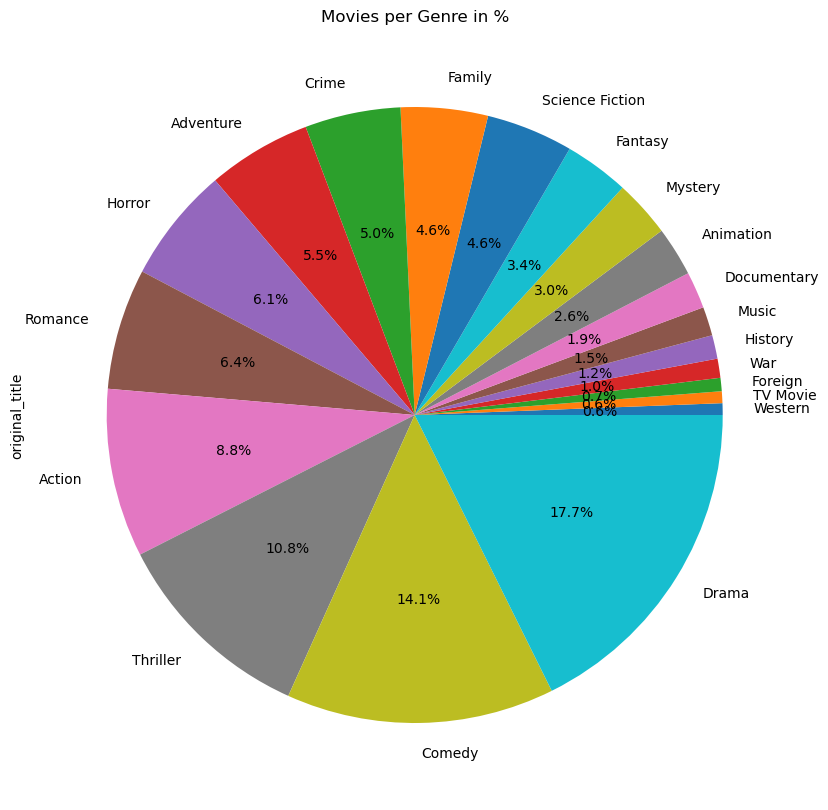

```python
genres_count['original_title'].plot.pie(title = 'Movies per Genre in %',autopct='%1.1f%%',figsize = (10,10))
```

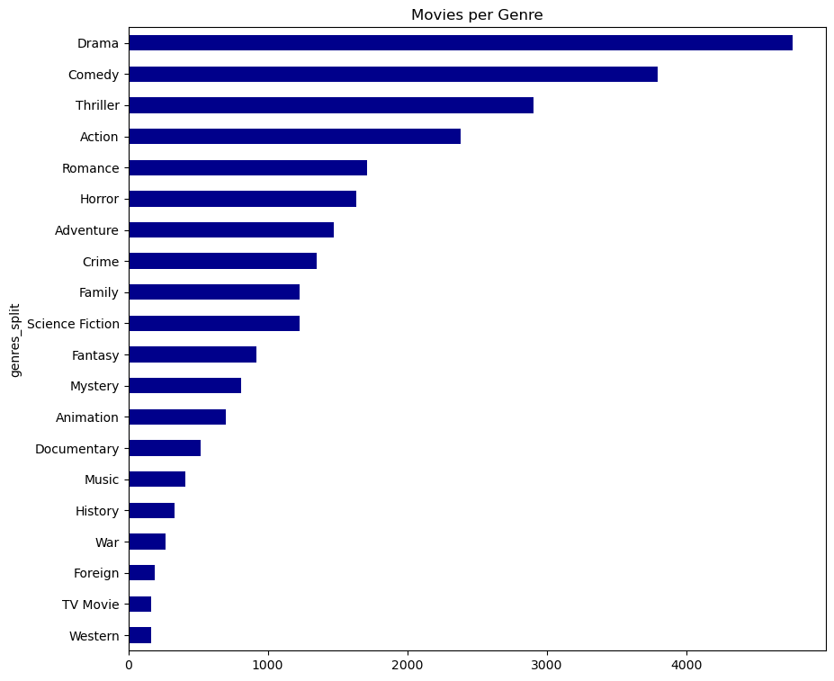

```python
genres_count['original_title'].plot.barh(title = 'Movies per Genre',color = 'DarkBlue', figsize = (10,9))
```

2. Which genres have the high avg. budget, revenue and profit?

```python
genres_avg = movies_genre.groupby('genres_split')[['budget','revenue','profit','popularity','vote_average','vote_count','runtime']].mean()
pd.options.display.float_format = '{:2f}'.format

genres_avg
```

| genres_split | budget | revenue | profit | popularity | vote_average | vote_count | runtime |
| --- | --- | --- | --- | --- | --- | --- | --- |
| Action | 27727820.331376 | 72794732.002517 | 45066911.671141 | 0.926274 | 5.787752 | 392.993708 | 104.917785 |
| Adventure | 37543694.530931 | 113137861.069341 | 75594166.538409 | 1.154259 | 5.940585 | 513.125085 | 106.173351 |
| Animation | 23159781.606581 | 75256062.223176 | 52096280.616595 | 0.852182 | 6.403147 | 303.000000 | 68.181688 |
| Comedy | 13297915.618244 | 37526242.072238 | 24228326.453994 | 0.592607 | 5.905167 | 176.436330 | 96.745057 |
| Crime | 17663801.124815 | 42368661.645495 | 24704860.520679 | 0.744930 | 6.124889 | 278.805022 | 106.917282 |
| Documentary | 577149.148077 | 2041106.994231 | 1463957.846154 | 0.181432 | 6.908462 | 35.105769 | 102.651923 |
| Drama | 11880717.773529 | 29232255.725840 | 17351537.952311 | 0.591495 | 6.165546 | 182.544538 | 110.478151 |
| Family | 23359337.420796 | 72433176.373680 | 49073838.952884 | 0.786668 | 5.997563 | 272.320877 | 89.603574 |
| Fantasy | 32612585.348253 | 96313657.081878 | 63701071.733624 | 0.992840 | 5.863537 | 420.741266 | 100.736900 |
| Foreign | 1451434.925532 | 1520459.835106 | 69024.909574 | 0.191496 | 5.981383 | 16.627660 | 107.228723 |
| History | 18594919.302395 | 32011793.215569 | 13416873.913174 | 0.575936 | 6.410479 | 183.772455 | 136.206587 |
| Horror | 6226529.210751 | 16822808.624313 | 10596279.413561 | 0.465357 | 5.337447 | 120.059866 | 94.424557 |
| Music | 9438627.549020 | 28571768.691176 | 19133141.142157 | 0.487321 | 6.480392 | 124.340686 | 105.137255 |
| Mystery | 16119270.062963 | 40217566.661728 | 24098296.598765 | 0.690012 | 5.946790 | 236.998765 | 105.928395 |
| Romance | 12531271.847547 | 35691972.327103 | 23160700.479556 | 0.592082 | 6.042874 | 166.070678 | 106.891355 |
| Science Fiction | 24972680.524003 | 70140558.034174 | 45167877.510171 | 1.001548 | 5.665582 | 437.096013 | 99.419854 |
| TV Movie | 267664.670659 | 251497.005988 | -16167.664671 | 0.270896 | 5.788024 | 34.365269 | 91.982036 |
| Thriller | 17207693.769178 | 41728417.543860 | 24520723.774682 | 0.741563 | 5.750671 | 255.484348 | 103.247678 |
| War | 20891886.103704 | 47605183.300000 | 26713297.196296 | 0.727683 | 6.297778 | 270.733333 | 127.625926 |
| Western | 18974107.975758 | 28568709.284848 | 9594601.309091 | 0.590615 | 6.083030 | 205.739394 | 117.575758 |

```python
genres_avg.sort_values('budget', ascending = True, inplace = True)
```

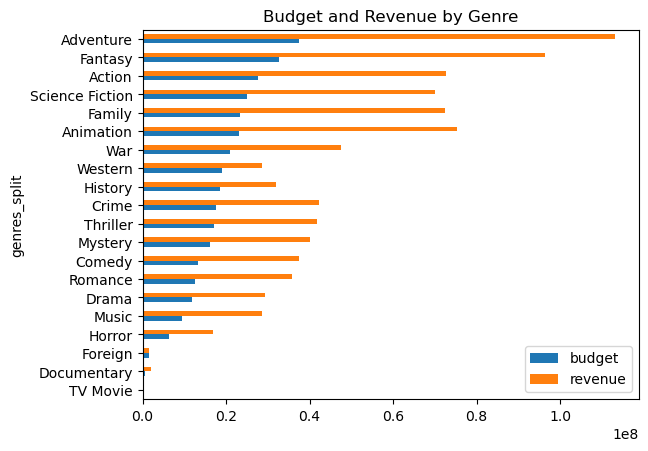

```python
genres_avg[['budget','revenue']].plot.barh(title = 'Budget and Revenue by Genre')
```

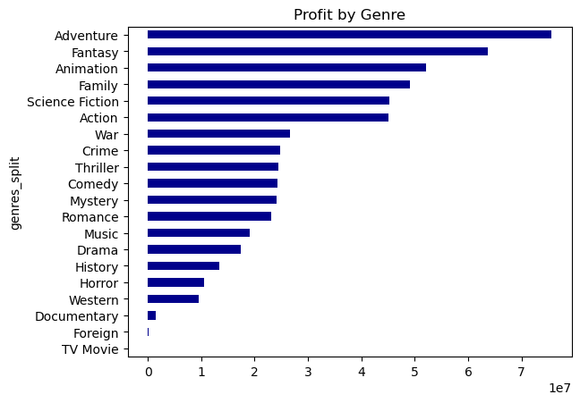

```python
genres_avg['profit'].sort_values(ascending = True).plot.barh(title = 'Profit by Genre', color = 'DarkBlue')
```

3. Which genres have the high avg. popularity?

   Adventure, Science Fiction, Fantasy

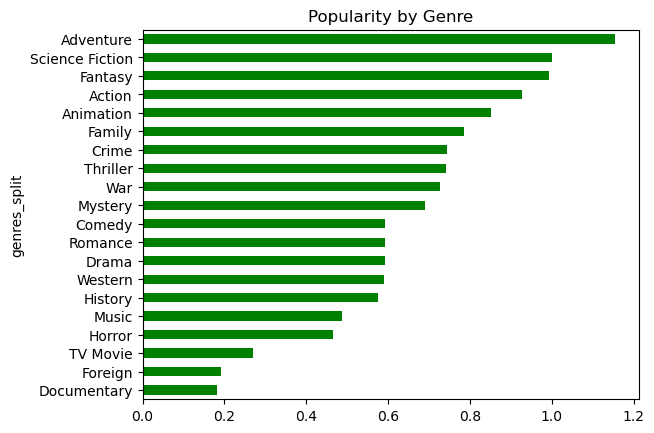

```python
genres_avg['popularity'].sort_values(ascending = True).plot.barh(title = 'Popularity by Genre', color = 'Green')
```

```python
movies_pop = movies_genre.groupby('genres_split')['popularity'].max().sort_values(ascending = False)
movies_pop
```

```
genres_split
Action            32.985763
Thriller          32.985763
Science Fiction   32.985763
Adventure         32.985763
Drama             24.949134
Fantasy           11.173104
Mystery            9.363643
Crime              9.335014
Western            9.110700
Family             8.691294
Comedy             8.691294
Animation          8.691294
Horror             8.411577
War                8.110711
History            8.110711
Romance            6.715966
Music              4.780419
TV Movie           1.844119
Documentary        1.005772
Foreign            0.741302
Name: popularity, dtype: float64
```

4. Which genres have the highest number of movies with an voting avg. >=8?

   Drama, Crime, Documentary

```python
genre_vote = movies_genre[(movies_genre['vote_count'] >=50) & (movies_genre['vote_average'] >=8)]
genre_vote.head()
```

|  | popularity | budget | revenue | profit | original_title | runtime | production_companies | vote_count | vote_average | release_year | genres_split |
| --- | --- | --- | --- | --- | --- | --- | --- | --- | --- | --- | --- |
| 9 | 6.326804 | 175000000 | 853708609 | 678708609 | Inside Out | 94 | Walt Disney Pictures\|Pixar Animation Studios\|W... | 3935 | 8.000000 | 2015 | Comedy |
| 9 | 6.326804 | 175000000 | 853708609 | 678708609 | Inside Out | 94 | Walt Disney Pictures\|Pixar Animation Studios\|W... | 3935 | 8.000000 | 2015 | Animation |
| 9 | 6.326804 | 175000000 | 853708609 | 678708609 | Inside Out | 94 | Walt Disney Pictures\|Pixar Animation Studios\|W... | 3935 | 8.000000 | 2015 | Family |
| 35 | 3.557846 | 6000000 | 35401758 | 29401758 | Room | 117 | Element Pictures\|No Trace Camping\|A24\|Duperele... | 1520 | 8.000000 | 2015 | Drama |
| 35 | 3.557846 | 6000000 | 35401758 | 29401758 | Room | 117 | Element Pictures\|No Trace Camping\|A24\|Duperele... | 1520 | 8.000000 | 2015 | Thriller |

```python
high_vote = pd.DataFrame(genre_vote.groupby('genres_split')['vote_average'].count()).sort_values('vote_average',ascending = False)
high_vote
```

| genres_split | vote_average |
| --- | --- |
| Drama | 21 |
| Crime | 10 |
| Documentary | 7 |
| Thriller | 6 |
| Animation | 5 |
| Family | 5 |
| Adventure | 4 |
| Action | 3 |
| Romance | 3 |
| Science Fiction | 3 |
| War | 3 |
| Comedy | 3 |
| Music | 2 |
| History | 2 |
| Fantasy | 2 |
| Mystery | 1 |
| Horror | 1 |

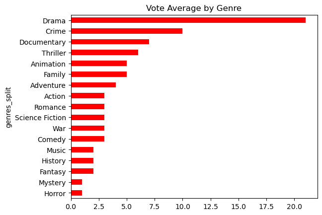

```python
high_vote['vote_average'].sort_values(ascending = True).plot.barh(title = 'Vote Average by Genre', color = 'Red')
```

Hypothesis (H's)

1. The best movies according to vote.avg return high profit and revenue
2. The best movies according to popularity return high profit and revenue
3. Take a look at profit per genre per year

```python
movies.drop_duplicates(inplace = True)
movies['profit'] = movies['revenue'] - movies['budget']
movies_genre1 = movies[['popularity','budget','revenue','profit','original_title','runtime','genres','production_companies','vote_count','vote_average','release_year']]
```

```python
movies_genre1.head()
```

|  | popularity | budget | revenue | profit | original_title | runtime | genres | production_companies | vote_count | vote_average | release_year |
| --- | --- | --- | --- | --- | --- | --- | --- | --- | --- | --- | --- |
| 0 | 32.985763 | 150000000 | 1513528810 | 1363528810 | Jurassic World | 124 | Action\|Adventure\|Science Fiction\|Thriller | Universal Studios\|Amblin Entertainment\|Legenda... | 5562 | 6.500000 | 2015 |
| 1 | 28.419936 | 150000000 | 378436354 | 228436354 | Mad Max: Fury Road | 120 | Action\|Adventure\|Science Fiction\|Thriller | Village Roadshow Pictures\|Kennedy Miller Produ... | 6185 | 7.100000 | 2015 |
| 2 | 13.112507 | 110000000 | 295238201 | 185238201 | Insurgent | 119 | Adventure\|Science Fiction\|Thriller | Summit Entertainment\|Mandeville Films\|Red Wago... | 2480 | 6.300000 | 2015 |
| 3 | 11.173104 | 200000000 | 2068178225 | 1868178225 | Star Wars: The Force Awakens | 136 | Action\|Adventure\|Science Fiction\|Fantasy | Lucasfilm\|Truenorth Productions\|Bad Robot | 5292 | 7.500000 | 2015 |
| 4 | 9.335014 | 190000000 | 1506249360 | 1316249360 | Furious 7 | 137 | Action\|Crime\|Thriller | Universal Pictures\|Original Film\|Media Rights ... | 2947 | 7.300000 | 2015 |

1. The best movies according to vote.avg return high profit and revenue

```python
movies_counted = movies_genre1[(movies_genre1['vote_count'] >=50)]

movies_counted[['popularity','budget','revenue','profit','runtime','vote_count','vote_average']].corr(method = 'spearman')
```

|  | popularity | budget | revenue | profit | runtime | vote_count | vote_average |
| --- | --- | --- | --- | --- | --- | --- | --- |
| popularity | 1.000000 | 0.484952 | 0.588594 | 0.498092 | 0.230214 | 0.768888 | 0.189226 |
| budget | 0.484952 | 1.000000 | 0.714733 | 0.334345 | 0.360001 | 0.554412 | -0.044050 |
| revenue | 0.588594 | 0.714733 | 1.000000 | 0.842278 | 0.341469 | 0.682550 | 0.112201 |
| profit | 0.498092 | 0.334345 | 0.842278 | 1.000000 | 0.211947 | 0.583606 | 0.198580 |
| runtime | 0.230214 | 0.360001 | 0.341469 | 0.211947 | 1.000000 | 0.263164 | 0.286082 |
| vote_count | 0.768888 | 0.554412 | 0.682550 | 0.583606 | 0.263164 | 1.000000 | 0.285084 |
| vote_average | 0.189226 | -0.044050 | 0.112201 | 0.198580 | 0.286082 | 0.285084 | 1.000000 |

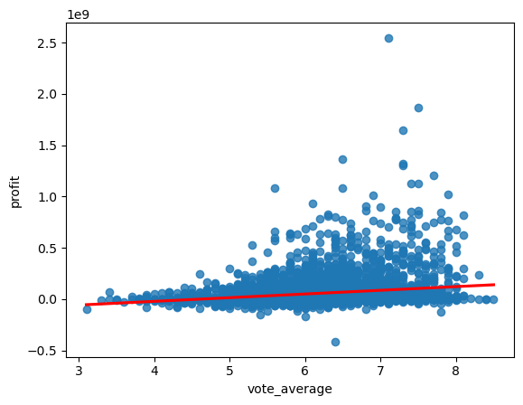

```python
import seaborn as sns
sns.regplot(x='vote_average', y= 'profit', data = movies_counted, line_kws = {'color': 'red'})
```

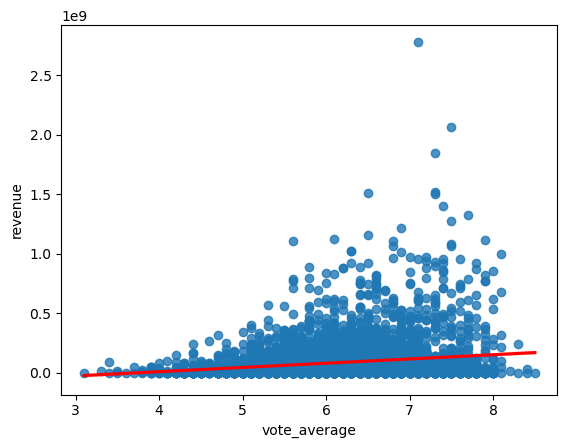

```python
sns.regplot(x='vote_average', y= 'revenue', data = movies_counted, line_kws = {'color': 'red'})
```

2. The best movies according to popularity return high profit and revenue

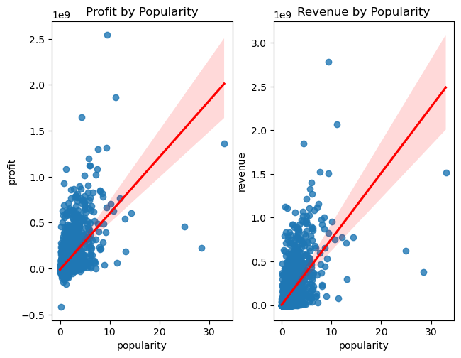

```python
import matplotlib.pyplot as plt

fig, axs = plt.subplots(1,2)
plt.tight_layout()
plt.figure(figsize = (20,5))

sns.regplot(x='popularity', y= 'profit', data = movies_counted, line_kws = {'color': 'red'},ax = axs[0] )
axs[0].set_title('Profit by Popularity')

sns.regplot(x='popularity', y= 'revenue', data = movies_counted, line_kws = {'color': 'red'},ax = axs[1] )
axs[1].set_title('Revenue by Popularity')
```

3. Take a look at profit per genre per year

```python
movies_genre.head()
```

|  | popularity | budget | revenue | profit | original_title | runtime | production_companies | vote_count | vote_average | release_year | genres_split |
| --- | --- | --- | --- | --- | --- | --- | --- | --- | --- | --- | --- |
| 0 | 32.985763 | 150000000 | 1513528810 | 1363528810 | Jurassic World | 124 | Universal Studios\|Amblin Entertainment\|Legenda... | 5562 | 6.500000 | 2015 | Action |
| 0 | 32.985763 | 150000000 | 1513528810 | 1363528810 | Jurassic World | 124 | Universal Studios\|Amblin Entertainment\|Legenda... | 5562 | 6.500000 | 2015 | Adventure |
| 0 | 32.985763 | 150000000 | 1513528810 | 1363528810 | Jurassic World | 124 | Universal Studios\|Amblin Entertainment\|Legenda... | 5562 | 6.500000 | 2015 | Science Fiction |
| 0 | 32.985763 | 150000000 | 1513528810 | 1363528810 | Jurassic World | 124 | Universal Studios\|Amblin Entertainment\|Legenda... | 5562 | 6.500000 | 2015 | Thriller |
| 1 | 28.419936 | 150000000 | 378436354 | 228436354 | Mad Max: Fury Road | 120 | Village Roadshow Pictures\|Kennedy Miller Produ... | 6185 | 7.100000 | 2015 | Action |

```python
time_genre = pd.DataFrame(movies_genre.groupby(['release_year','genres_split'])['profit'].mean())
time_genre.head()
```

| release_year | genres_split | profit |
| --- | --- | --- |
| 1960 | Action | 6363125.000000 |
|  | Adventure | 431000.000000 |
|  | Comedy | 5258750.000000 |
|  | Crime | 0.000000 |
|  | Drama | 8245619.384615 |

```python
final_genre = pd.pivot_table(time_genre, values = 'profit',index = 'genres_split', columns = 'release_year')
final_genre.head()
```

| release_year genres_split | 1960 | 1961 | 1962 | 1963 | 1964 | 1965 | 1966 | 1967 | 1968 | 1969 | 1970 | ... | 2005 | 2006 | 2007 | 2008 | 2009 | 2010 | 2011 | 2012 | 2013 | 2014 | 2015 |
| --- | --- | --- | --- | --- | --- | --- | --- | --- | --- | --- | --- | --- | --- | --- | --- | --- | --- | --- | --- | --- | --- | --- | --- |
| Action | 6363125.000000 | 2457142.857143 | 10437500.000000 | 14999691.250000 | 24280000.000000 | 16104504.777778 | 324785.714286 | 21732786.428571 | 8868478.833333 | 5861449.300000 | 7735913.454545 | ... | 32379154.185714 | 38048623.212500 | 45977444.052632 | 47642764.404040 | 57555510.740741 | 34571030.355140 | 51968078.252174 | 71910257.424242 | 47431725.628099 | 69943650.015504 | 90399046.747664 |
| Adventure | 431000.000000 | 39130002.333333 | 21214285.714286 | 9428395.000000 | 24123400.000000 | 25124276.333333 | 791563.636364 | 49281873.857143 | 15122159.400000 | 16651809.400000 | 11406377.666667 | ... | 70756754.320755 | 64895200.090909 | 83916731.083333 | 55016526.809524 | 113364919.736111 | 98125646.677966 | 113343224.564516 | 162549574.300000 | 100638113.402985 | 120373306.985075 | 144787868.971014 |
| Animation | NaN | 211880014.000000 | NaN | 0.000000 | 0.000000 | 0.000000 | -105000.000000 | 100921706.000000 | 0.000000 | 0.000000 | 25837628.500000 | ... | 40307312.153846 | 39047734.974359 | 67147670.531250 | 51907242.575758 | 48862898.250000 | 58455658.640000 | 63420098.934783 | 69231546.875000 | 93718795.261905 | 64313463.250000 | 83691174.384615 |
| Comedy | 5258750.000000 | 22198001.400000 | 1599974.800000 | 765591.923077 | 7080111.375000 | 3264285.714286 | -149550.000000 | 10135087.470588 | -1277777.777778 | -125000.000000 | 11901488.583333 | ... | 22147617.440559 | 24944308.174194 | 30674848.549669 | 21483012.426036 | 24741982.808081 | 23154807.875740 | 27241358.720930 | 25631999.136364 | 25068455.091429 | 26648786.864865 | 33703819.067901 |
| Crime | 0.000000 | 18828411.000000 | 3709948.666667 | 369526.750000 | 1723307.300000 | -22500.000000 | -275560.000000 | 12899678.714286 | 6762174.600000 | 31482963.000000 | -2125000.000000 | ... | 15680793.688889 | 21551432.962264 | 16700048.400000 | 31258696.854839 | 11016642.307692 | 13490412.320000 | 25395271.625000 | 29522925.555556 | 23248589.507042 | 5903014.230769 | 61286524.372549 |

5 rows × 56 columns

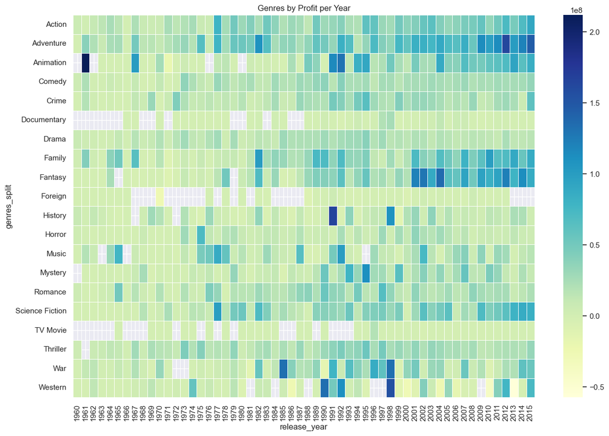

```python
sns.set(rc = {'figure.figsize': (15,10)})
sns.heatmap(final_genre, cmap = 'YlGnBu', linewidths = .5)
plt.title('Genres by Profit per Year')
```

4. Take a look at Revenue per genre per year

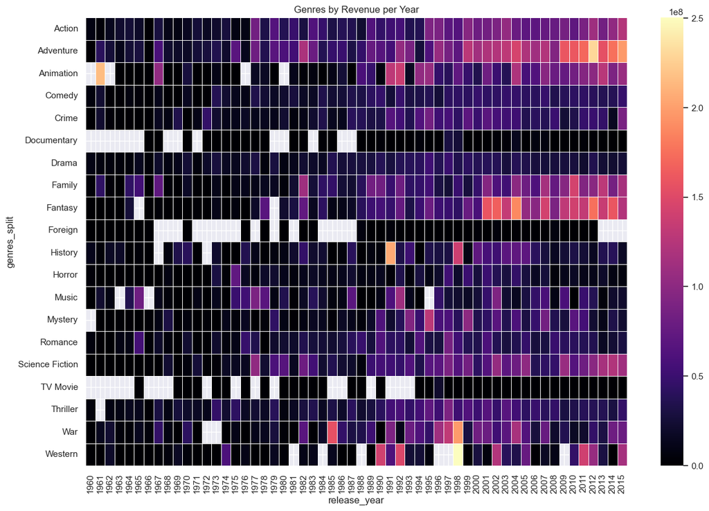

```python
time_genre1 = pd.DataFrame(movies_genre.groupby(['release_year','genres_split'])['revenue'].mean())
final_genre1 = pd.pivot_table(time_genre1, values = 'revenue',index = 'genres_split', columns = 'release_year')

sns.set(rc = {'figure.figsize': (15,10)})
sns.heatmap(final_genre1, cmap = 'magma', linewidths = .5)
plt.title('Genres by Revenue per Year')
```

```python
movies_genre[(movies_genre['release_year']==2012) & (movies_genre['genres_split']=='Adventure')].sort_values(by = 'revenue',ascending = False).head(10)
```

|  | popularity | budget | revenue | profit | original_title | runtime | production_companies | vote_count | vote_average | release_year | genres_split |
| --- | --- | --- | --- | --- | --- | --- | --- | --- | --- | --- | --- |
| 4361 | 7.637767 | 220000000 | 1519557910 | 1299557910 | The Avengers | 143 | Marvel Studios | 8903 | 7.300000 | 2012 | Adventure |
| 4365 | 5.603587 | 200000000 | 1108561013 | 908561013 | Skyfall | 143 | Columbia Pictures | 6137 | 6.800000 | 2012 | Adventure |
| 4367 | 4.218933 | 250000000 | 1017003568 | 767003568 | The Hobbit: An Unexpected Journey | 169 | WingNut Films\|New Line Cinema\|Metro-Goldwyn-Ma... | 6417 | 6.900000 | 2012 | Adventure |
| 4375 | 3.135776 | 95000000 | 877244782 | 782244782 | Ice Age: Continental Drift | 88 | Blue Sky Studios\|Twentieth Century Fox Animation | 1920 | 6.200000 | 2012 | Adventure |
| 4413 | 1.586368 | 120000000 | 829000000 | 709000000 | The Twilight Saga: Breaking Dawn - Part 2 | 115 | Summit Entertainment\|Sunswept Entertainment\|Te... | 1668 | 6.100000 | 2012 | Adventure |
| 4370 | 3.702647 | 215000000 | 752215857 | 537215857 | The Amazing Spider-Man | 136 | Columbia Pictures\|Laura Ziskin Productions\|Mar... | 4837 | 6.400000 | 2012 | Adventure |
| 4382 | 2.571099 | 75000000 | 691210692 | 616210692 | The Hunger Games | 142 | Lionsgate\|Color Force | 7080 | 6.700000 | 2012 | Adventure |
| 4374 | 3.140080 | 120000000 | 609016565 | 489016565 | Life of Pi | 127 | Ingenious Film Partners\|Ingenious Media\|Dune E... | 4338 | 7.100000 | 2012 | Adventure |
| 4371 | 3.626741 | 185000000 | 538983207 | 353983207 | Brave | 93 | Walt Disney Pictures\|Pixar Animation Studios | 3206 | 6.600000 | 2012 | Adventure |
| 4379 | 2.858742 | 165000000 | 471222889 | 306222889 | Wreck-It Ralph | 108 | Walt Disney Animation Studios | 3492 | 7.000000 | 2012 | Adventure |